# Scenarios with K_LINFcvp2, Stock Synthesis EM runs

Kathryn Doering

6/24/2021

## Description of simulation runs

100 simulations of 4 different OM scenarios were run:

```r
# fixed values ----
mydir <- getwd()
outer_folder <- file.path(mydir, "Scen_K_LINFcvp2")
outer_folder_output <- file.path(mydir, "output", basename(outer_folder))
cases <- list.dirs(outer_folder_output, full.names = FALSE, recursive = FALSE)
run_date <-  "2021_06_24"
print(cases)
```

```
## [1] "Baseline_KnifeEdge40cm_Fp4_Mp05_K_LINF_cvp2"
## [2] "Baseline_LessSteepSel_L95eq45_K_LINF_cvp2"
## [3] "OneWayTrip_FRising10YrsFr0top25_Mp15_K_LINF_cvp2"
## [4] "OneWayTrip_LessSteepSel_L95eq45_K_LINF_cvp2"
```

For each of the OM Scenarios, there were 100 data sets, so each iteration of a scenario used a different dataset from the OM.

For each OM scenario, 2 SS estimation models were run: one that used 5 platoons and one that only had 1 platoon. Stock Synthesis version 3.30.16 was used for the runs, but we could update to 3.30.17.

After the SS models were run, they were summarized into CSV files for different model quantities.

## Setup results

```r
# load pkgs, set options -----
library(r4ss)
source(file.path(mydir, "code", "SS_run_functions.R"))
library(ggplot2)
library(dplyr)
library(tidyr)
library(purrr)

Rdata_folder <- file.path(mydir, "Rdata_output", basename(outer_folder))
```

Read in the csv files generated from the runs, and add as components of a list of lists:

```r
# read in csv files ----
csv_list <- lapply(cases, function(icase, outer_folder) {
  mydir.dat <- file.path(outer_folder, icase, "IBMData")
  out_ab <- file.path(mydir.dat, '../ResultsSSab')
  out_pl <- file.path(mydir.dat, '../ResultsSSpl')
  partable_plat <- read.csv(file.path(out_pl, "SS_parameters.csv"))
  partable_noplat <- read.csv(file = file.path(out_ab, "SS_parameters.csv"))
  recruits_plat <- read.csv(file = file.path(out_pl, "SS_recruitment.csv"))
  recruits_noplat <- read.csv(file.path(out_ab, "SS_recruitment.csv"))
  F_plat <- read.csv(file.path(out_pl, "SS_exploitation.csv"))
  F_noplat <- read.csv(file.path(out_ab, "SS_exploitation.csv"))
  N30plus_plat <- read.csv(file.path(out_pl, "SS_numbers30plus.csv"))
  N30plus_noplat <- read.csv(file.path(out_ab, "SS_numbers30plus.csv"))
  B30plus_plat <- read.csv(file.path(out_pl, "SS_biomass30plus.csv"))
  B30plus_noplat <- read.csv(file.path(out_ab, "SS_biomass30plus.csv"))
  plat_list <- list(partable = partable_plat,
                    recruits = recruits_plat,
                    F_val = F_plat,
                    N30plus = N30plus_plat,
                    B30plus = B30plus_plat)
  noplat_list <- list(partable = partable_noplat,
                    recruits = recruits_noplat,
                    F_val = F_noplat,
                    N30plus = N30plus_noplat,
                    B30plus = B30plus_noplat)
  val_list <- list(platoons = plat_list,
                   no_platoons = noplat_list)
  val_list
}, outer_folder = outer_folder)
names(csv_list) <- cases # 1 list per case; within each case list, each csv file is a list of components
```

## Check convergence of models

Get the parameter tables:

```r
# look at iterations that didn't converge ----

partbl_df_plat <- mapply(make_plotting_df,
                         scen_list = csv_list, scen_name = names(csv_list),
                         MoreArgs = list(platoons = TRUE, metric = "partable"),
                         SIMPLIFY = FALSE)
partbl_df_noplat <- mapply(make_plotting_df,
                           scen_list = csv_list, scen_name = names(csv_list),
                           MoreArgs = list(platoons = FALSE, metric = "partable"),
                           SIMPLIFY = FALSE)
partbl_df_plat <- do.call(rbind, partbl_df_plat)
partbl_df_noplat <- do.call(rbind, partbl_df_noplat)
partbl_df <- rbind(partbl_df_plat, partbl_df_noplat)
head(partbl_df)
```

```
##                                               run max_gradient converged
## Baseline_KnifeEdge40cm_Fp4_Mp05_K_LINF_cvp2.1   1  3.84918e-05      TRUE
## Baseline_KnifeEdge40cm_Fp4_Mp05_K_LINF_cvp2.2   2  7.43189e-05      TRUE
## Baseline_KnifeEdge40cm_Fp4_Mp05_K_LINF_cvp2.3   3  8.30594e-05      TRUE
## Baseline_KnifeEdge40cm_Fp4_Mp05_K_LINF_cvp2.4   4  2.15634e-04      TRUE
## Baseline_KnifeEdge40cm_Fp4_Mp05_K_LINF_cvp2.5   5  5.02569e-05      TRUE
## Baseline_KnifeEdge40cm_Fp4_Mp05_K_LINF_cvp2.6   6  6.60208e-05      TRUE
##                                                       K  Linf_mm   CV_old
## Baseline_KnifeEdge40cm_Fp4_Mp05_K_LINF_cvp2.1 0.0669847 1055.250 0.340338
## Baseline_KnifeEdge40cm_Fp4_Mp05_K_LINF_cvp2.2 0.0690157 1046.470 0.273208
## Baseline_KnifeEdge40cm_Fp4_Mp05_K_LINF_cvp2.3 0.0926796  850.088 0.326043
## Baseline_KnifeEdge40cm_Fp4_Mp05_K_LINF_cvp2.4 0.0702913  984.792 0.384065
## Baseline_KnifeEdge40cm_Fp4_Mp05_K_LINF_cvp2.5 0.0801928  909.940 0.367179
## Baseline_KnifeEdge40cm_Fp4_Mp05_K_LINF_cvp2.6 0.0891838  903.313 0.286303
##                                                L50_mm   L95_mm R0_thousands
## Baseline_KnifeEdge40cm_Fp4_Mp05_K_LINF_cvp2.1 396.545 405.8784     22541.20
## Baseline_KnifeEdge40cm_Fp4_Mp05_K_LINF_cvp2.2 399.759 413.7920     22765.47
## Baseline_KnifeEdge40cm_Fp4_Mp05_K_LINF_cvp2.3 399.163 412.4650     24149.04
## Baseline_KnifeEdge40cm_Fp4_Mp05_K_LINF_cvp2.4 398.015 408.9583     23479.90
## Baseline_KnifeEdge40cm_Fp4_Mp05_K_LINF_cvp2.5 396.964 407.9789     23444.71
## Baseline_KnifeEdge40cm_Fp4_Mp05_K_LINF_cvp2.6 396.458 406.5612     23486.94
##                                                                                      scen
## Baseline_KnifeEdge40cm_Fp4_Mp05_K_LINF_cvp2.1 Baseline_KnifeEdge40cm_Fp4_Mp05_K_LINF_cvp2
## Baseline_KnifeEdge40cm_Fp4_Mp05_K_LINF_cvp2.2 Baseline_KnifeEdge40cm_Fp4_Mp05_K_LINF_cvp2
## Baseline_KnifeEdge40cm_Fp4_Mp05_K_LINF_cvp2.3 Baseline_KnifeEdge40cm_Fp4_Mp05_K_LINF_cvp2
## Baseline_KnifeEdge40cm_Fp4_Mp05_K_LINF_cvp2.4 Baseline_KnifeEdge40cm_Fp4_Mp05_K_LINF_cvp2
## Baseline_KnifeEdge40cm_Fp4_Mp05_K_LINF_cvp2.5 Baseline_KnifeEdge40cm_Fp4_Mp05_K_LINF_cvp2
## Baseline_KnifeEdge40cm_Fp4_Mp05_K_LINF_cvp2.6 Baseline_KnifeEdge40cm_Fp4_Mp05_K_LINF_cvp2
##                                               platoons
## Baseline_KnifeEdge40cm_Fp4_Mp05_K_LINF_cvp2.1     TRUE
## Baseline_KnifeEdge40cm_Fp4_Mp05_K_LINF_cvp2.2     TRUE
## Baseline_KnifeEdge40cm_Fp4_Mp05_K_LINF_cvp2.3     TRUE
## Baseline_KnifeEdge40cm_Fp4_Mp05_K_LINF_cvp2.4     TRUE
## Baseline_KnifeEdge40cm_Fp4_Mp05_K_LINF_cvp2.5     TRUE
## Baseline_KnifeEdge40cm_Fp4_Mp05_K_LINF_cvp2.6     TRUE
```

Now, find which iterations didn’t converge:

```r
# create table so can remove non converged runs from the other datasets.
not_converged <- partbl_df[partbl_df$converged == FALSE, c("run", "scen", "platoons")]
rownames(not_converged) <- as.character(1:nrow(not_converged))
not_converged
```

```
##   run                                             scen platoons
## 1  35      Baseline_KnifeEdge40cm_Fp4_Mp05_K_LINF_cvp2     TRUE
## 2  87      Baseline_KnifeEdge40cm_Fp4_Mp05_K_LINF_cvp2     TRUE
## 3  85 OneWayTrip_FRising10YrsFr0top25_Mp15_K_LINF_cvp2     TRUE
```

There were a total of 3 iterations total that didn’t converge, all of which were models with platoons. Looking more into this, I think these model runs exited on error for some reason.

Also, remove the non-converged iterations from `partbl_df` before plotting:

```r
partbl_df <- partbl_df[partbl_df$converged == TRUE, ]
```

## Plots and descriptions of quantities from the EMs

### Plots of the parameter values:

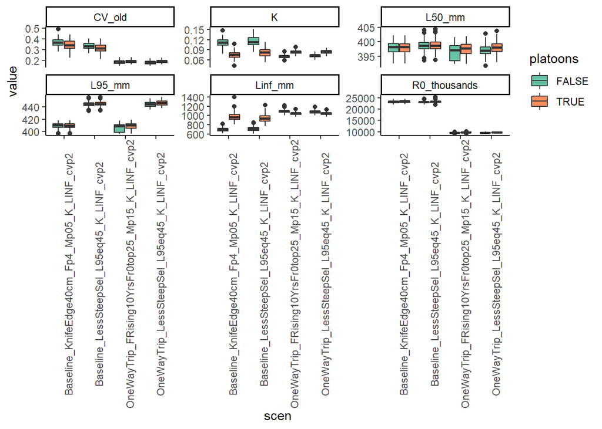

```r
partbl_long <- gather(partbl_df, key = "parameter", value = "value", 4:9)

ggplot(partbl_long, aes(x = scen, y = value)) +
  geom_boxplot(aes(fill = platoons))+
  scale_fill_brewer(palette = "Set2")+
  facet_wrap(~parameter, scales = "free_y")+
  theme_classic()+
  theme(axis.text.x = element_text(angle = 90))
```

Note that CV_old seems to be hitting a bound in some of the scenarios, so we may need to consider re-running these after changing the bound within the SS EM (I think the true value was 0.20)?

Overall, there are differences between platoons and no platoons runs. Likewise, the relationship between Linf and K is shifted down for no platoon runs compared to platton runs:

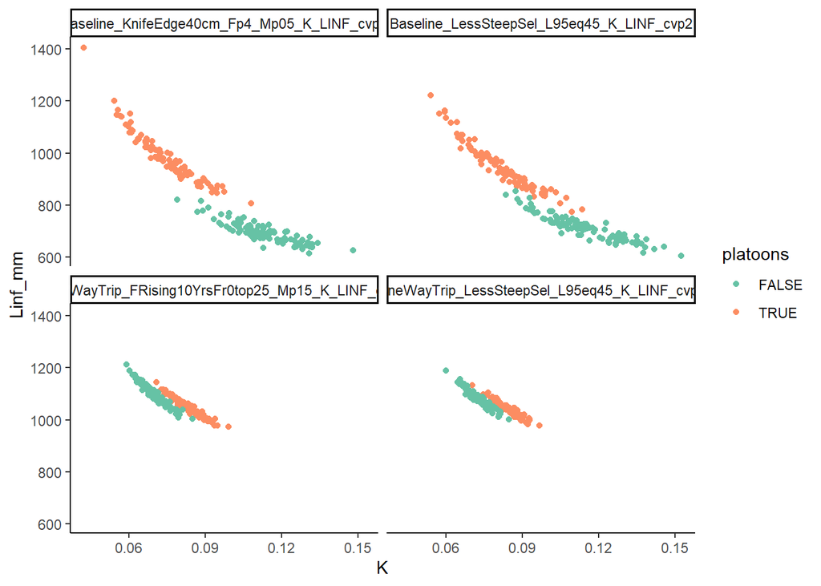

```r
ggplot(partbl_df, aes(x = K, y = Linf_mm)) +
  geom_point(aes(color = platoons))+
  scale_color_brewer(palette = "Set2")+
  facet_wrap(~scen)+
  theme_classic()
```

### Other quantities

Other quantities were extracted from `csv_list` and the non-converged iterations were removed.

Plots of fishing mortality, first a spaghetti plot showing all runs:

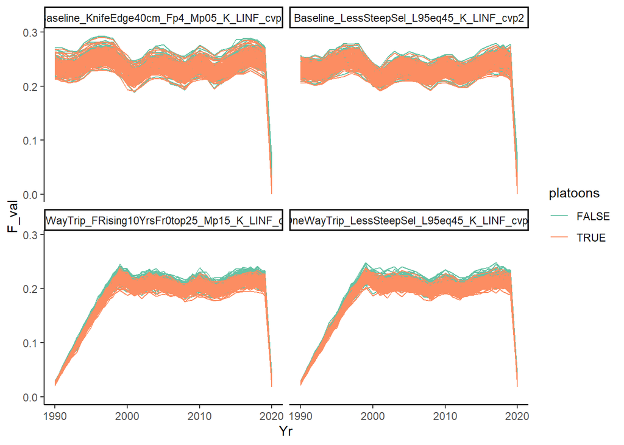

Next, a plot of Fishing mortality showing a quick summary of runs:

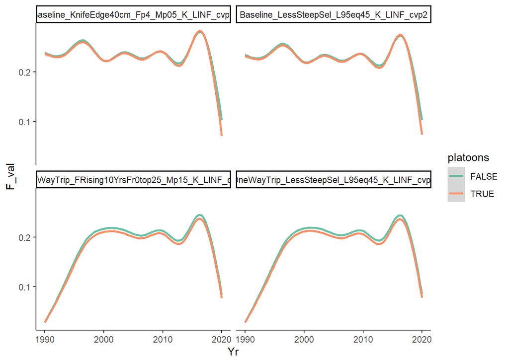

Similar plots were made for other quantities.

Plots of Numbers of fish for fish >= 30 (unsure of units):

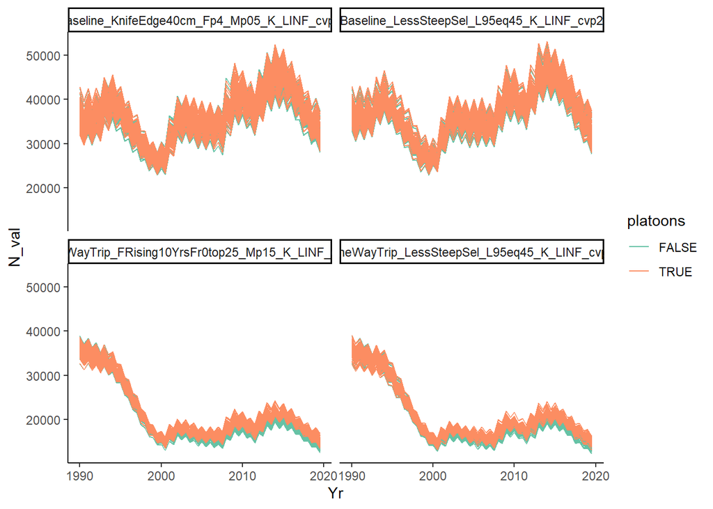

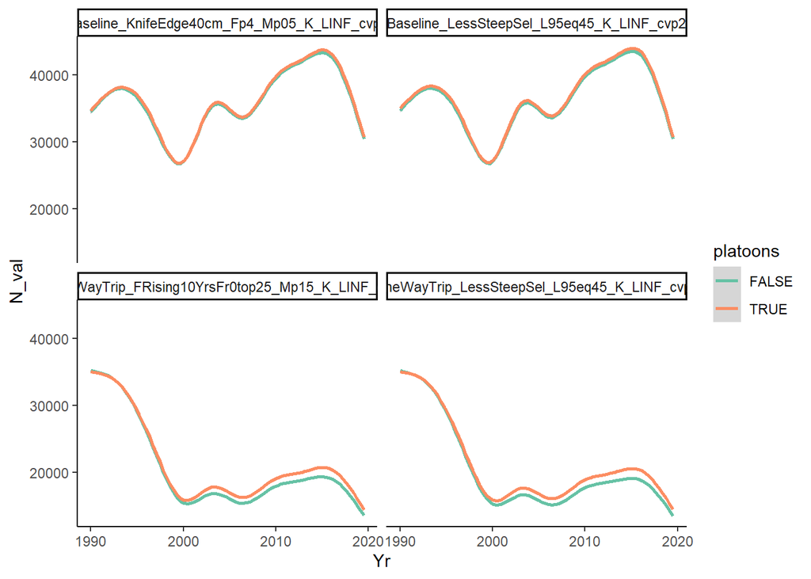

Plots of biomass for fish >= 30 (unsure of units):

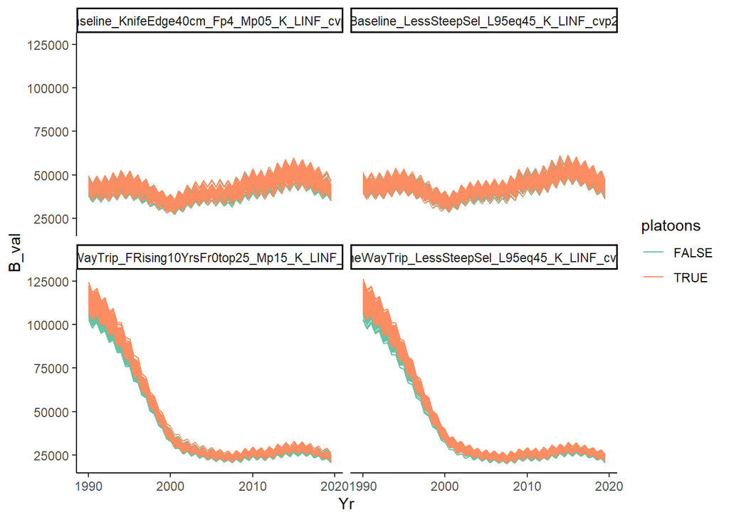

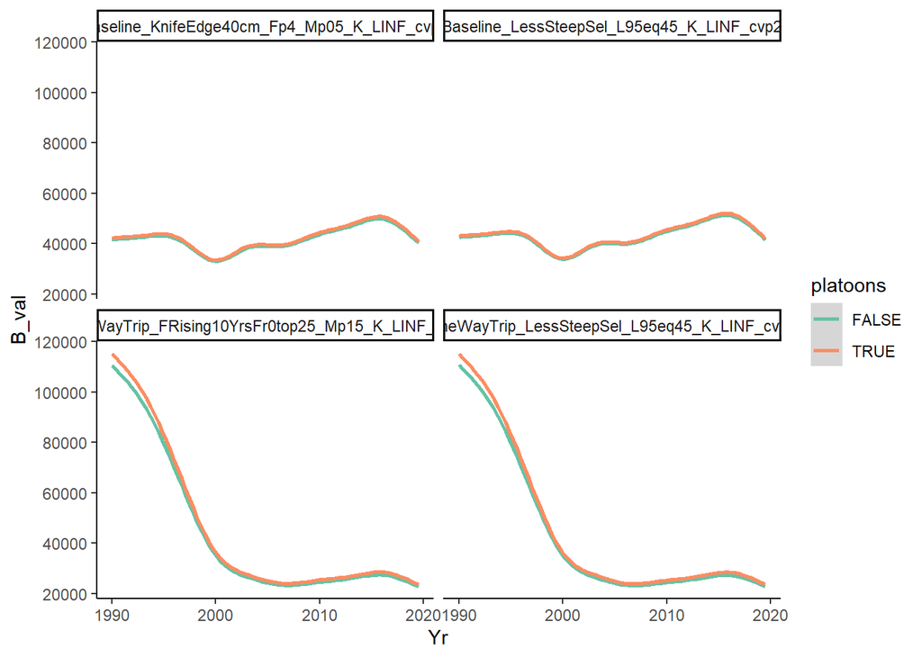

Plots of recruits (numbers?):

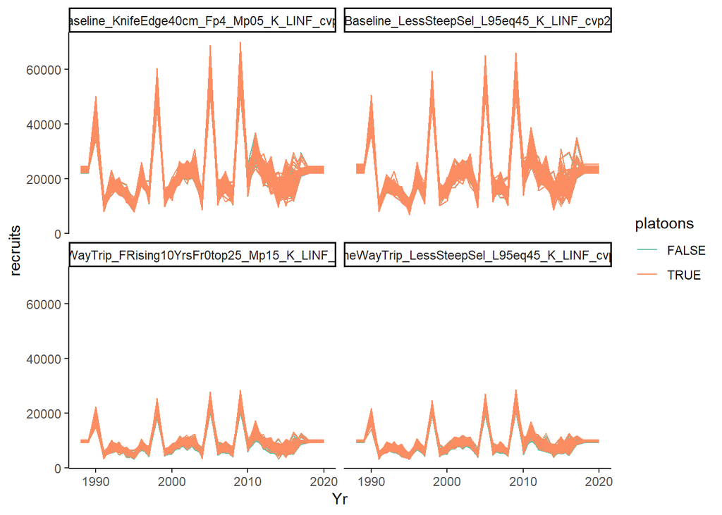

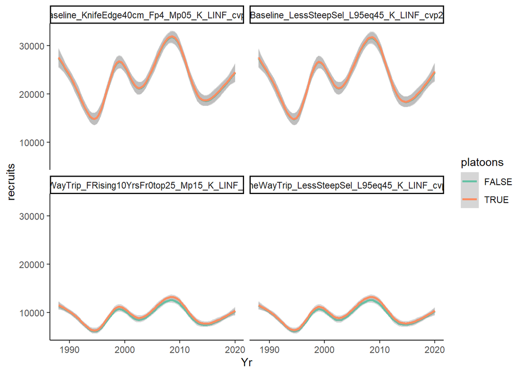

## TODO

Investigate the few models that still have params on bounds